#’ — #’ title: Satellite Remote Sensing #’ subtitle: Analyze Satellite Data #’ week: 10 #’ type: Case Study #’ reading: #’ tasks: #’ - Extract a timeseries from a single location in a netcdf file (part 1) #’ - Calculate a monthly climatology from a weekely timeseries (part 2) #’ - Summarize Land Surface Temperature by Land Cover (part 3) #’ — #’

#’ #’ # Tasks #’

```r
# install.packages("rasterVis")
# install.packages("kableExtra")
library(raster)
library(rasterVis)
library(rgdal)
library(ggmap)
library(tidyverse)
library(knitr)
library(kableExtra)
```

```r
# New Packages
library(ncdf4) # to import data from netcdf format

## # Create a folder to hold the downloaded data
dir.create("data",showWarnings = F) #create a folder to hold the data

lulc_url="https://github.com/adammwilson/DataScienceData/blob/master/inst/extdata/appeears/MCD12Q1.051_aid0001.nc?raw=true"
lst_url="https://github.com/adammwilson/DataScienceData/blob/master/inst/extdata/appeears/MOD11A2.006_aid0001.nc?raw=true"

## # download them
download.file(lulc_url,destfile="data/MCD12Q1.051_aid0001.nc", mode="wb")
download.file(lst_url,destfile="data/MOD11A2.006_aid0001.nc", mode="wb")
```

#’ #’ #’ You should also edit your .gitignore file (in your tasks repository folder) to include `*data*` on one line. This will prevent git from adding these files.  
#’ #’ #’ ## Load data into R

```r
lulc=stack("data/MCD12Q1.051_aid0001.nc",varname="Land_Cover_Type_1")
lst=stack("data/MOD11A2.006_aid0001.nc",varname="LST_Day_1km")
```

#’ #’ ## Explore LULC data

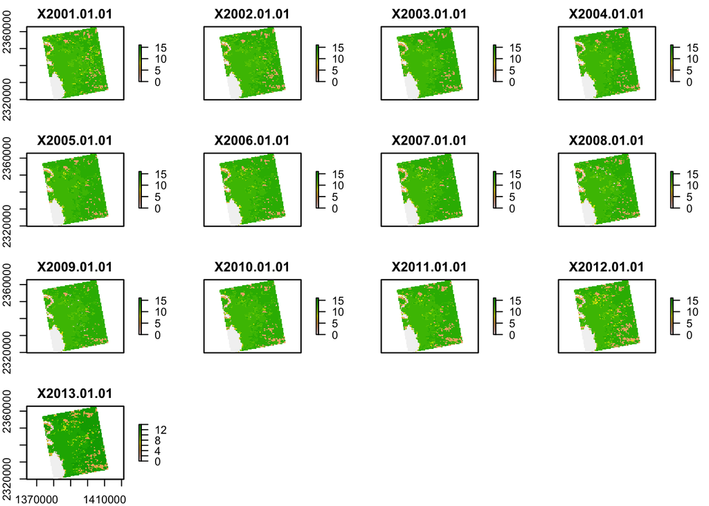

```r
plot(lulc)
```

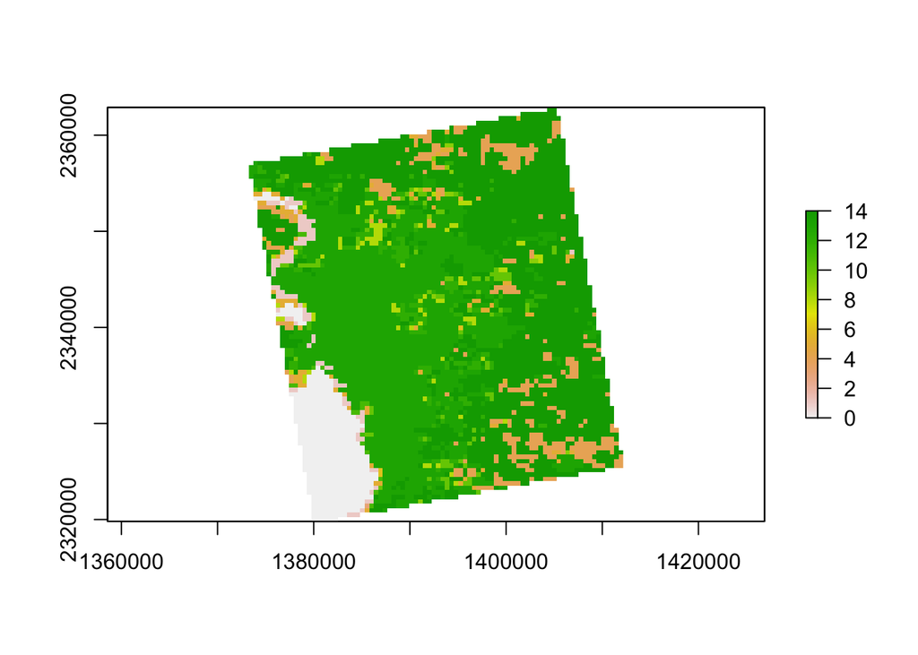

```r
#'
#'
#' We'll just pick one year to work with to keep this simple:
## ---- warning=F---------------------------------------------------------------
lulc=lulc[[13]]
plot(lulc)
```

#’ #’ ### Process landcover data #’ #’ Assign land cover clases from [MODIS website](https://lpdaac.usgs.gov/dataset_discovery/modis/modis_products_table/mcd12q1) #’

```r
Land_Cover_Type_1 = c(
  Water = 0,
  `Evergreen Needleleaf forest` = 1,
  `Evergreen Broadleaf forest` = 2,
  `Deciduous Needleleaf forest` = 3,
  `Deciduous Broadleaf forest` = 4,
  `Mixed forest` = 5,
  `Closed shrublands` = 6,
  `Open shrublands` = 7,
  `Woody savannas` = 8,
  Savannas = 9,
  Grasslands = 10,
  `Permanent wetlands` = 11,
  Croplands = 12,
  `Urban & built-up` = 13,
  `Cropland/Natural vegetation mosaic` = 14,
  `Snow & ice` = 15,
  `Barren/Sparsely vegetated` = 16,
  Unclassified = 254,
  NoDataFill = 255)

lcd=data.frame(
  ID=Land_Cover_Type_1,
  landcover=names(Land_Cover_Type_1),
  col=c("#000080","#008000","#00FF00", "#99CC00","#99FF99", "#339966", "#993366", "#FFCC99", "#CCFFCC", "#FFCC00", "#FF9900", "#006699", "#FFFF00", "#FF0000", "#999966", "#FFFFFF", "#808080", "#000000", "#000000"),
  stringsAsFactors = F)
# colors from https://lpdaac.usgs.gov/about/news_archive/modisterra_land_cover_types_yearly_l3_global_005deg_cmg_mod12c1
kable(head(lcd))
```

|  | ID | landcover | col |
| --- | --- | --- | --- |
| Water | 0 | Water | #000080 |
| Evergreen Needleleaf forest | 1 | Evergreen Needleleaf forest | #008000 |
| Evergreen Broadleaf forest | 2 | Evergreen Broadleaf forest | #00FF00 |
| Deciduous Needleleaf forest | 3 | Deciduous Needleleaf forest | #99CC00 |
| Deciduous Broadleaf forest | 4 | Deciduous Broadleaf forest | #99FF99 |
| Mixed forest | 5 | Mixed forest | #339966 |

#’ #’ Convert LULC raster into a ‘factor’ (categorical) raster. This requires building the Raster Attribute Table (RAT). Unfortunately, this is a bit of manual process as follows.

```r
# convert to raster (easy)
lulc=as.factor(lulc)

# update the RAT with a left join
levels(lulc)=left_join(levels(lulc)[[1]],lcd)
```

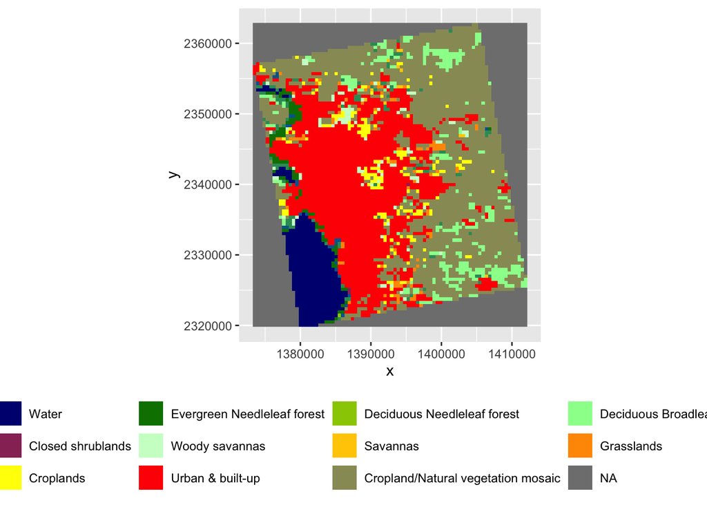

```r
# plot it
gplot(lulc)+
  geom_raster(aes(fill=as.factor(value)))+
  scale_fill_manual(values=levels(lulc)[[1]]$col,
                    labels=levels(lulc)[[1]]$landcover,
                    name="Landcover Type")+
  coord_equal()+
  theme(legend.position = "bottom")+
  guides(fill=guide_legend(ncol=5,nrow=3,byrow=TRUE))
```

#’ # Land Surface Temperature

#’ #’ ## Convert LST to Degrees C #’ You can convert LST from Degrees Kelvin (K) to Celcius (C) with `offs()`. #’

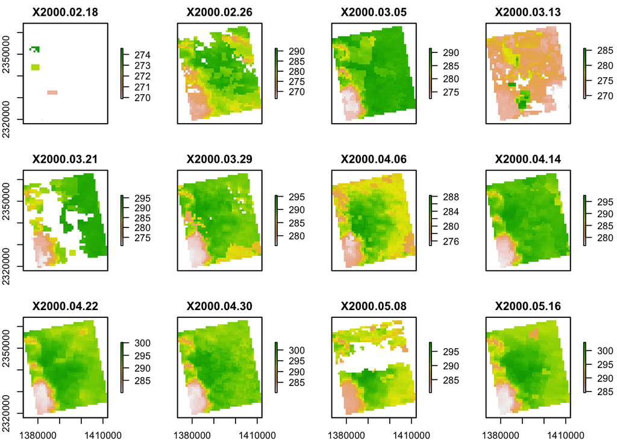

```r
## -----------------------------------------------------------------------------
plot(lst[[1:12]])
```

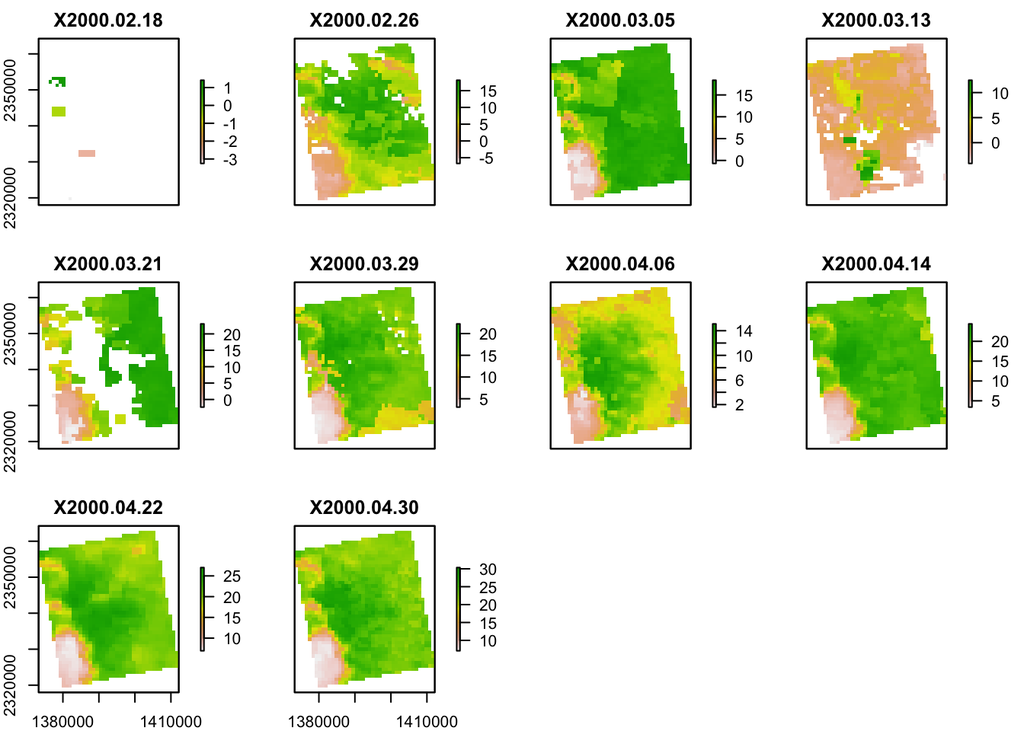

```r
offs(lst)=-273.15
plot(lst[[1:10]])
```

#’ ## Add Dates to Z (time) dimension #’ #’ The default layer names of the LST file include the date as follows: #’

```r
names(lst)[1:5]
```

```
## [1] "X2000.02.18" "X2000.02.26" "X2000.03.05" "X2000.03.13" "X2000.03.21"
```

```r
tdates=names(lst)%>%
  sub(pattern="X",replacement="")%>%
  as.Date("%Y.%m.%d")

names(lst)=1:nlayers(lst)
lst=setZ(lst,tdates)
```

```r
#' 1. Use
lw=SpatialPoints(data.frame(x= -78.791547,y=43.007211))
###to define a new Spatial Point at that location.

#' 2. Set the projection of your point with
projection(lw)="+proj=longlat"

#' 3. Transform the point to the projection of the raster using
lw=spTransform(lw,crs(lst))

#' 4. Extract the LST data for that location
location=raster::extract(lst,lw,buffer=1000,fun=mean,na.rm=T)
location=t(location)
#You may want to transpose them with `t()` to convert it from a wide matrix to long vector.
```

```r
#' 5. Extract the dates for each layer with
dates=getZ(lst)
#combine them into a data.frame with the transposed raster values.
data.frame(dates)
```

[output not shown]

[output cut: 797 more lines]

```r
combined=cbind.data.frame(dates,location)
```

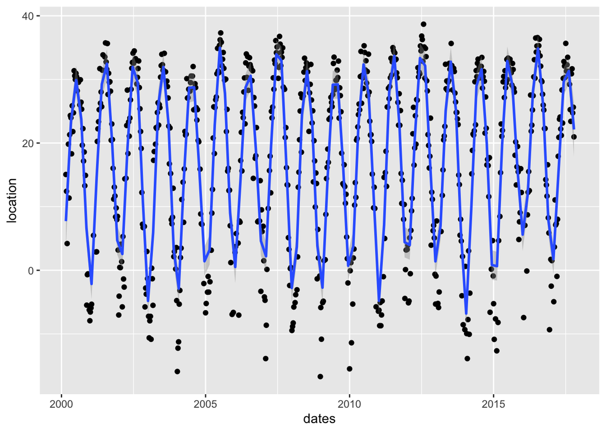

```r
#' 6. Plot it with `ggplot()` including points for the raw data and a smooth version as a line.  You will probably want to adjust both `span` and `n` in `geom_smooth`.
ggplot(combined,aes(x=dates,y=location))+
  geom_point()+
  geom_smooth(span=0.05,n=100)
```

#’ #’ See the `library(rts)` for more timeseries related functions. #’ #’ #’ # Part 2: Summarize weekly data to monthly climatologies #’

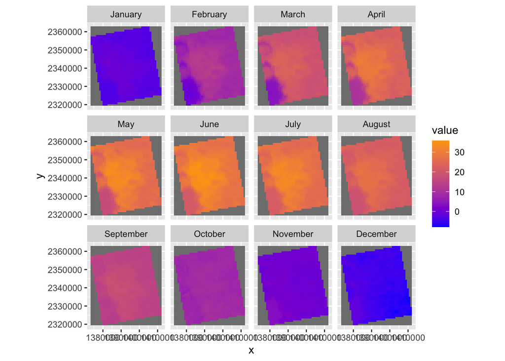

```r
#' 1. First make a variable called `` by converting the dates to months using
tmonth=as.numeric(format(getZ(lst),"%m"))
#' 2. Use `stackApply()` to summarize the mean value per month (using the `tmonth` variable you just created) and save the results as `lst_month`.
lst_month=stackApply(lst,tmonth,fun = mean)
#' 3. Set the names of the layers to months with `names(lst_month)=month.name`
names(lst_month)=month.name
#' 4. Plot the map for each month with `gplot()` in the RasterVis Package.
rasterVis::gplot(lst_month)+
  geom_tile(aes(fill=value))+
  facet_wrap(~ variable) +
  scale_fill_gradient(low = 'blue', high = 'orange') +
  coord_equal()
```

```r
#' 5. Calculate the monthly mean for the entire image with `cellStats(lst_month,mean)`
monthlymean=cellStats(lst_month,mean)
```